# Modeling and prediction for movies

## Part 4: Modeling

**1. Specify which variables to consider for the full model**

The variables considered are title_type, genre, runtime, thtr_rel_year, imdb_rating, thtr_rel_month, thtr_rel_day, dvd_rel_year, dvd_rel_month, dvd_rel_day, best_pic_nom, best_pic_win, best_actor_win, best_actress_win, best_dir_win and top200_box for the full model.

**2. Reasoning for excluding certain variables**

Some variables are irrelevant for the analysis such as the rt_url and imdb_url. Others like audience_rating, critics_score, and so on are not independent, and show collinearity. Actors are also excluded because they are less contributive to a statistical analysis like this.

**3. Reasoning for choice of model selection method**

The reason for choosing a three-factor model is because it has highest adjusted R value compared to previous ones. There is no big increase in the R value from two factor to three factor. Whether it is the parsimonious model will need further investigations.

**4. Carrying out the model selection correctly**

The analysis starts from forward selection for linear regression. Adjusted R-square is used to determine if the variable is significant and thus be included in the final linear model. The overall correlation coefficient is 0.762044.The detailed analysis is illustrated in EDA.

**5. Model diagnostics**

**Linearity & Constant Variability**

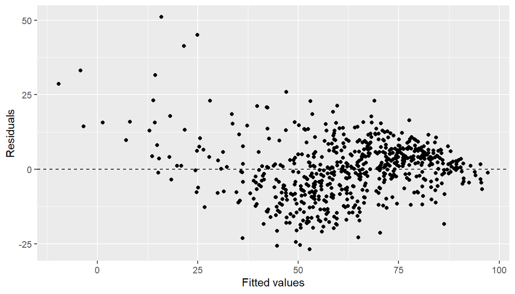

```r
ggplot(data = m34, aes(x = .fitted, y = .resid)) +
  geom_point() +
  geom_hline(yintercept = 0, linetype = "dashed") +
  xlab("Fitted values") +
  ylab("Residuals")
```

**Nearly Normal Residuals**

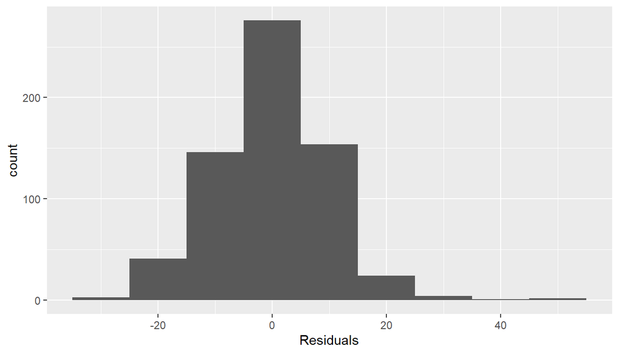

```r
ggplot(data = m34, aes(x = .resid)) +
  geom_histogram(binwidth = 10) +
  xlab("Residuals")
```

The residuals do show a nearly normal distribution centered at zero, and fairly symmetric, as shown in the plot above.

**Normal Probability Plot**

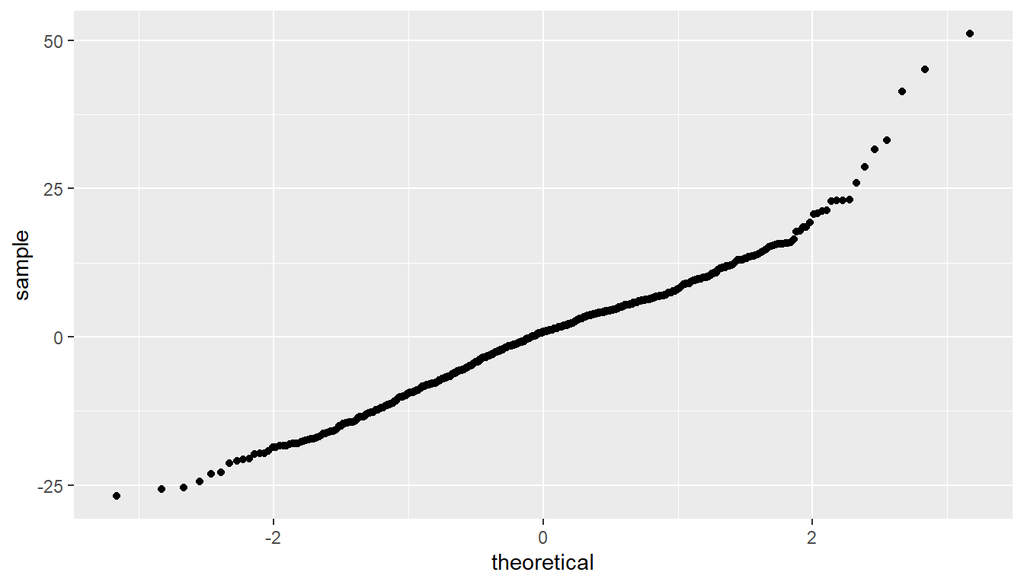

```r
ggplot(data = m34, aes(sample = .resid)) +
  stat_qq()
```

**6. Interpretation of model coefficients**

```r
summary(m34)
```

```
##
## Call:
## lm(formula = audience_score ~ imdb_rating + genre + thtr_rel_month,
##     data = movies)
##
## Residuals:
##     Min      1Q  Median      3Q     Max
## -26.870  -6.269   0.828   5.727  51.069
##
## Coefficients:
##                                Estimate Std. Error t value Pr(>|t|)
## (Intercept)                    -40.9872     2.7637 -14.831  < 2e-16 ***
## imdb_rating                     16.1032     0.4077  39.502  < 2e-16 ***
## genreAnimation                   9.9313     3.5094   2.830 0.004802 **
## genreArt House & International  -0.1722     2.9185  -0.059 0.952977
## genreComedy                      2.4086     1.6203   1.487 0.137625
## genreDocumentary                 1.8802     1.9603   0.959 0.337851
## genreDrama                       0.2880     1.3775   0.209 0.834465
## genreHorror                     -4.6314     2.3950  -1.934 0.053576 .
## genreMusical & Performing Arts   5.1605     3.1465   1.640 0.101479
## genreMystery & Suspense         -6.1204     1.7871  -3.425 0.000655 ***
## genreOther                       2.1246     2.7679   0.768 0.443015
## genreScience Fiction & Fantasy   0.5189     3.5097   0.148 0.882505
## thtr_rel_month                  -0.2057     0.1097  -1.876 0.061176 .
## ---
## Signif. codes:  0 '***' 0.001 '**' 0.01 '*' 0.05 '.' 0.1 ' ' 1
##
## Residual standard error: 9.865 on 638 degrees of freedom
## Multiple R-squared:  0.7664, Adjusted R-squared:  0.762
## F-statistic: 174.5 on 12 and 638 DF,  p-value: < 2.2e-16
```

From the summary statistics, we can see that the relationship between audience_score and imdb_rating is positive, an increase of one point in imdb_rating is associated with 16.1032 increase in audience_score. The p-value is extremely small suggesting the statistics significance of the estimate. The genre variable is less clear in that different genre do show different relationships with audience_score, some increase and other decrease. The p-values are less significant - the two show significance are Animation and Mystery & Suspense. Besides, the release month is negatively associated with audience_score as reflected in the negative of the slope. The overall model indicates an increase in adjusted R squared value when thtr_rel_month is factored in, although the p-value for t-statistics is only 6.12%. * * *

## Part 5: Prediction

```r
DrivingMissDaisy <- data.frame(genre = "Drama", imdb_rating = 7.4, thtr_rel_month = 6, audience_score = 81)
DMD <- round(predict(m34, DrivingMissDaisy), digit = 0)
c(DMD, DrivingMissDaisy$audience_score)
```

```
##  1
## 77 81
```

```r
predict(m34, DrivingMissDaisy, interval = 'prediction', level = 0.95)
```

```
##        fit      lwr      upr
## 1 77.23024 57.81705 96.64344
```

We are 95% confident that the audience_score of Driving Miss Daisy is in the range of 57.81705 to 96.64344.

## Part 6: Conclusion

After layers of analyses, we came to the realization that imdb_rating is highly associated with the audience_score. Other factors that increase the R-squared value are thtr_rel_month and genre but with less significance and with both negative and positive associations in their sub-categories. The audience_score is chosen as the response variable, if other variables such as critics_score or imdb_num_votes, the model may be different compared to the one illustrated in this analysis.